# MSnbase benchmarking

Laurent Gatto and Johannes Rainer

de Duve Institute, UCLouvain, Belgium  
Center for Biomedicine, EURAC, Bolzano, Italy

31 May 2019

#### Package

MSnbase 2.10.1

# 1 Introduction

In this vignette, we will document various timings and benchmarkings of the recent *MSnbase* development, that focuses on *on-disk* data access (as opposed to *in-memory*). More details about the new implementation are documented in the respective classes manual pages.

As a benchmarking dataset, we are going to use a subset of an TMT 6-plex experiment acquired on an LTQ Orbitrap Velos, that is distributed with the *msdata* package

```r
library("msdata")
f <- msdata::proteomics(full.names = TRUE,
                        pattern = "TMT_Erwinia_1uLSike_Top10HCD_isol2_45stepped_60min_01.mzML.gz")
basename(f)
```

```
## [1] "TMT_Erwinia_1uLSike_Top10HCD_isol2_45stepped_60min_01.mzML.gz"
```

We need to load the *MSnbase* package and set the session-wide verbosity flag to `FALSE`.

```r
library("MSnbase")
setMSnbaseVerbose(FALSE)
```

# 2 Benchmarking

## 2.1 Reading data

We first read the data using the original behaviour `readMSData` function by setting the `mode` argument to `"inMemory"` to generates an in-memory representation of the MS2-level raw data and measure the time needed for this operation.

```r
system.time(inmem <- readMSData(f, msLevel = 2,
                                mode = "inMemory",
                                centroided = TRUE))
```

```
##    user  system elapsed
##    6.72    0.19    7.91
```

Next, we use the `readMSData` function to generate an on-disk representation of the same data by setting `mode = "onDisk"`.

```r
system.time(ondisk <- readMSData(f, msLevel = 2,
                                  mode = "onDisk",
                                  centroided = TRUE))
```

```
##    user  system elapsed
##    2.51    0.18    2.67
```

Creating the on-disk experiment is considerable faster and scales to much bigger, multi-file data, both in terms of object creation time, but also in terms of object size (see next section). We must of course make sure that these two datasets are equivalent:

```r
all.equal(inmem, ondisk)
```

```
## [1] TRUE
```

## 2.2 Data size

To compare the size occupied in memory of these two objects, we are going to use the `object_size` function from the *pryr* package, which accounts for the data (the spectra) in the `assayData` environment (as opposed to the `object.size` function from the `utils` package).

```r
library("pryr")
object_size(inmem)
```

```
## 2.77 MB
```

```r
object_size(ondisk)
```

```
## 231 kB
```

The difference is explained by the fact that for `ondisk`, the spectra are not created and stored in memory; they are access on disk when needed, such as for example for plotting:

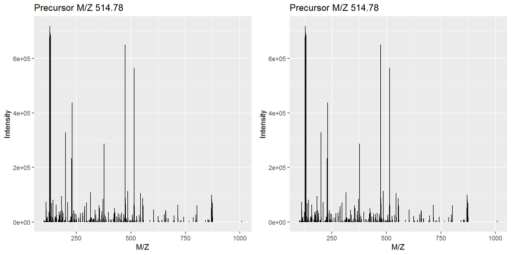

Figure 1: Plotting in-memory and on-disk spectra

```r
plot(inmem[[200]], full = TRUE)
plot(ondisk[[200]], full = TRUE)
```

## 2.3 Accessing spectra

The drawback of the on-disk representation is when the spectrum data has to actually be accessed. To compare access time, we are going to use the *microbenchmark* and repeat access 10 times to compare access to all 451 and a single spectrum in-memory (i.e. pre-loaded and constructed) and on-disk (i.e. on-the-fly access).

```r
library("microbenchmark")
mb <- microbenchmark(spectra(inmem),
                     inmem[[200]],
                     spectra(ondisk),
                     ondisk[[200]],
                     times = 10)
mb
```

```
## Unit: microseconds
##             expr        min         lq        mean      median         uq
##   spectra(inmem)     86.714     91.413    169.7539    190.5140    201.193
##     inmem[[200]]     30.328     44.425     68.0468     80.7335     87.568
##  spectra(ondisk) 474675.336 484548.308 505367.9181 499748.8295 519140.655
##    ondisk[[200]] 204682.709 208646.763 213555.3974 214906.3795 216733.346
##         max neval cld
##     262.276    10 a
##      93.975    10 a
##  555201.154    10   c
##  222170.678    10  b
```

On-disk access performance will depend on the read throughput of the disk. A comparison of the data import of the above file from an internal solid state drive and from an USB3 connected hard disk showed only small differences for the `onDisk` mode (1.07 *vs* 1.36 seconds), while no difference were observed for accessing individual or all spectra. Thus, for this particular setup, performance was about the same for SSD and HDD. This might however not apply to setting in which data import is performed in parallel from multiple files.

Data access does not prohibit interactive usage, such as plotting, for example, as it is about 1/2 seconds, which is an operation that is relatively rare, compared to subsetting and filtering, which are faster for on-disk data:

```r
i <- sample(length(inmem), 100)
system.time(inmem[i])
```

```
##    user  system elapsed
##    0.12    0.00    0.13
```

```r
system.time(ondisk[i])
```

```
##    user  system elapsed
##    0.01    0.00    0.02
```

Operations on the spectra data, such as peak picking, smoothing, cleaning, … are cleverly cached and only applied when the data is accessed, to minimise file access overhead. Finally, specific operations such as for example quantitation (see next section) are optimised for speed.

## 2.4 MS2 quantitation

Below, we perform TMT 6-plex reporter ions quantitation on the first 100 spectra and verify that the results are identical (ignoring feature names).

```r
system.time(eim <- quantify(inmem[1:100], reporters = TMT6,
                            method = "max"))
```

```
##    user  system elapsed
##    0.77    0.00   11.77
```

```r
system.time(eod <- quantify(ondisk[1:100], reporters = TMT6,
                            method = "max"))
```

```
##    user  system elapsed
##    0.31    0.04    0.36
```

```r
all.equal(eim, eod, check.attributes = FALSE)
```

```
## [1] TRUE
```

# 3 Notable differences *on-disk* and *in-memory* implementations

The `MSnExp` and `OnDiskMSnExp` documentation files and the *MSnbase developement* vignette provide more information about implementation details.

## 3.1 MS levels

*On-disk* support multiple MS levels in one object, while *in-memory* only supports a single level. While support for multiple MS levels could be added to the in-memory back-end, memory constrains make this pretty-much useless and will most likely never happen.

## 3.2 Serialisation

*In-memory* objects can be `save()`ed and `load()`ed, while *on-disk* can’t. As a workaround, the latter can be coerced to *in-memory* instances with `as(, "MSnExp")`. We would need `mzML` write support in *mzR* to be able to implement serialisation for *on-disk* data.

## 3.3 Data processing

Whenever possible, accessing and processing *on-disk* data is delayed (*lazy* processing). These operations are stored in a *processing queue* until the spectra are effectively instantiated.

## 3.4 Validity

The *on-disk* `validObject` method doesn’t verify the validity on the spectra (as there aren’t any to check). The `validateOnDiskMSnExp` function, on the other hand, instantiates all spectra and checks their validity (in addition to calling `validObject`).

# 4 Conclusions

This document focuses on speed and size improvements of the new on-disk `MSnExp` representation. The extend of these improvements will substantially increase for larger data.

For general functionality about the on-disk `MSnExp` data class and *MSnbase* in general, see other vignettes available with

```r
vignette(package = "MSnbase")
```